# Lab Week 9 - Simple Linear Regression

Allison Horst

### 1. Objectives

- One more chi-square, with visualization
- Example of rank-based tests for rank / medians comparison (Mann-Whitney U)
- Simple linear regression by OLS in R
- Check assumptions (diagnostic plots)
- Visualize linear model, and summarize in text
- Calculate Pearson’s *r*
- Make predictions for new values

### 2. Chi-square, revisited:

```r
df <- data.frame(state = c("California", "Oregon", "Washington", "Colorado"),
                 yes = c(54, 130, 67, 85),
                 no = c(102, 115, 95, 71))

# Check out the data frame that you just created from scratch:
df
```

```
##        state yes  no
## 1 California  54 102
## 2     Oregon 130 115
## 3 Washington  67  95
## 4   Colorado  85  71
```

**We ask:** Does proportions of residents who went skiing last season differ significantly between Californians, Oregonians, Washingtonians, and Coloradans?

Let’s look at a table of proportions (remember `janitor::adorn_()`):

```r
df_prop <- df %>%
  janitor::adorn_percentages(denominator = "row") %>%
  janitor::adorn_pct_formatting(digits = 2) %>%
  janitor::adorn_ns(position = "front")

df_prop
```

```
##       state          yes           no
##  California  54 (34.62%) 102 (65.38%)
##      Oregon 130 (53.06%) 115 (46.94%)
##  Washington  67 (41.36%)  95 (58.64%)
##    Colorado  85 (54.49%)  71 (45.51%)
```

So yeah, it looks like we might expect to find a significant difference. Let’s run chi-square to see:

```r
# Remember, first get a contingency table of ONLY counts
# Last week we just removed the first column
# Here, we use column_to_rownames to just make the first column a rowname instead
df_ct <- df %>%
  column_to_rownames('state')

# Notice how it changes:
df_ct
```

```
##            yes  no
## California  54 102
## Oregon     130 115
## Washington  67  95
## Colorado    85  71
```

```r
# Then we run chi-square:
ski_chi <- chisq.test(df_ct)

# And to see the results:
ski_chi
```

```
##
##  Pearson's Chi-squared test
##
## data:  df_ct
## X-squared = 18.791, df = 3, p-value = 0.0003019
```

Since p < 0.05, we retain the alternative hypothesis that skiing and state are not independent. In other words: “There are significant differences in skiing habits (yes / no last season) based on state of residence ($\chi$<sup>2</sup>(3) = 18.79, *p* < 0.001).”

Our follow-up question should be: *What’s driving the significant association?*

```r
#Standardized residuals > |2| indicates strong divergence from null hypothesis scenario

ski_chi$stdres
```

```
##                  yes        no
## California -3.427665  3.427665
## Oregon      2.445671 -2.445671
## Washington -1.557454  1.557454
## Colorado    2.194059 -2.194059
```

```r
# All but Washington are significantly different from expected if there were truly no significant differences in proportions.

# Then we can also follow-up by doing pairwise chi-square comparisons (just compare two states at a time) (not doing that here...)
```

### 3. A rank-based test example (Mann-Whitney U to compare unpaired ranks)

In lecture we discussed non-parametric rank-based alternatives to some of the hypothesis tests we’ve been doing to compare means. Those were:

- Mann-Whitney U to compare ranks (medians) between two unpaired samples
- Wilcoxon Signed-Rank to compare ranks (medians) between two paired samples
- Kruskall-Wallis to compare ranks (medians) between > 2 samples

As an example, let’s make some mock “unpaired” data and perform Mann-Whitney U using the `wilcox.test()` function (you’d also use this for a paired Wilcoxon-Signed-Rank test, with an additional ‘paired = TRUE’ argument).

First, create two samples `gp_1` and `gp_2`:

```r
# Remember, use set.seed() to create a "pseudorandom" sample
# sample.int: creates random samples from 1 - n, of size = ?, with replacement:

set.seed(1414)
gp_1 <- sample.int(20, size = 15, replace = TRUE)

set.seed(1424)
gp_2 <- sample.int(30, size = 15, replace = TRUE)
```

For example, imagine that those are rankings that people give a candidate on a scale from 1 - 30, and we want to know if there is a significant difference.

We ask: Is there a significant difference in ranks (medians) between the two groups?

Here, we’ll perform Mann-Whitney U:

```r
# Is there a significant difference in ranks (medians)?
my_mwu <- wilcox.test(gp_1, gp_2)
my_mwu
```

```
##
##  Wilcoxon rank sum test with continuity correction
##
## data:  gp_1 and gp_2
## W = 86, p-value = 0.28
## alternative hypothesis: true location shift is not equal to 0
```

```r
# No significant difference in rank (median)
# If data are PAIRED, add argument 'paired = TRUE'
```

Though not doing it today, see `kruskal.test` for more information about a rank-based test for comparing medians across > 2 groups.

### 4. Simple linear regression

We’ll exploring the relationship between two continuous variables, using the `iris` dataset

Here, we’ll explore petal length vs. petal width.

#### A. Look at it:

Always. This should always be the first thing.

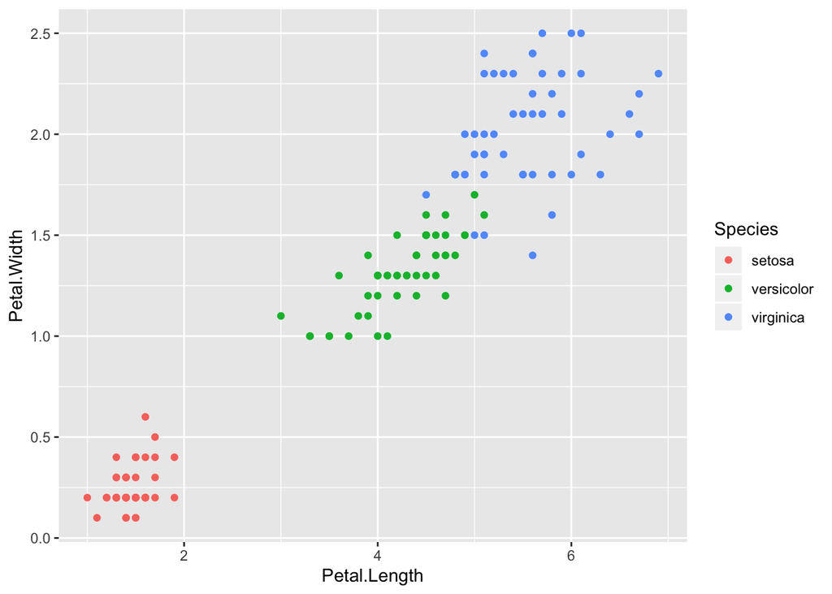

```r
# Exploratory (we'll make a final plot later)
ggplot(data = iris, aes(x = Petal.Length, y = Petal.Width)) +
  geom_point(aes(color = Species))
```

And ask:

- Does it look like a linear relationship makes sense?
- Do we have any concerns about modeling as a linear relationship?
- Any outliers?
- Initial thoughts about homoscedasticity (explored more later)?

Here, it looks like overall a linear relationship between petal length and petal width makes sense (although a case could be made that the smaller group, which contains all obserations for setosa irises, should be modeled separately).

#### B. Model it

Once we’ve decided that a linear relationship makes sense, we’ll model it using `lm()`.

Note that we haven’t checked all assumptions yet. That’s because a lot of our assumptions for linear regression are based on model *residuals* (e.g. normality & homoscedasticity of residuals), which we can’t calculate until after we find the predicted values from the model ($residual = y_{actual} - y_{predicted}$).

So make the model first:

```r
iris_lm <- lm(Petal.Width ~ Petal.Length, data = iris)
summary(iris_lm)
```

```
##
## Call:
## lm(formula = Petal.Width ~ Petal.Length, data = iris)
##
## Residuals:
##      Min       1Q   Median       3Q      Max
## -0.56515 -0.12358 -0.01898  0.13288  0.64272
##
## Coefficients:
##               Estimate Std. Error t value Pr(>|t|)
## (Intercept)  -0.363076   0.039762  -9.131  4.7e-16 ***
## Petal.Length  0.415755   0.009582  43.387  < 2e-16 ***
## ---
## Signif. codes:  0 '***' 0.001 '**' 0.01 '*' 0.05 '.' 0.1 ' ' 1
##
## Residual standard error: 0.2065 on 148 degrees of freedom
## Multiple R-squared:  0.9271, Adjusted R-squared:  0.9266
## F-statistic:  1882 on 1 and 148 DF,  p-value: < 2.2e-16
```

```r
# Look in lecture notes to see what the different pieces of the output are telling us.
# Are the individual coefficients significantly different from zero?
# Is the model overall significant?

# For comparison, forcing y-intercept to zero:
iris_lm_2 <- lm(Petal.Width ~ Petal.Length + 0, data = iris)
summary(iris_lm_2)
```

```
##
## Call:
## lm(formula = Petal.Width ~ Petal.Length + 0, data = iris)
##
## Residuals:
##      Min       1Q   Median       3Q      Max
## -0.48446 -0.24366 -0.13699  0.08642  0.68379
##
## Coefficients:
##              Estimate Std. Error t value Pr(>|t|)
## Petal.Length 0.336511   0.005063   66.46   <2e-16 ***
## ---
## Signif. codes:  0 '***' 0.001 '**' 0.01 '*' 0.05 '.' 0.1 ' ' 1
##
## Residual standard error: 0.2573 on 149 degrees of freedom
## Multiple R-squared:  0.9674, Adjusted R-squared:  0.9672
## F-statistic:  4417 on 1 and 149 DF,  p-value: < 2.2e-16
```

Let’s say we pick the first model (`lm_1`):

- The slope is 0.4157554
- The y-intercept is -0.3630755

But trying to get all of the statistical information from the `summary()` function would be kind of a mess. We can also use `broom::tidy()` to get the model outputs in nice data frame format:

```r
iris_lm_tidy <- broom::tidy(iris_lm)
iris_lm_tidy
```

```
## # A tibble: 2 x 5
##   term         estimate std.error statistic  p.value
##   <chr>           <dbl>     <dbl>     <dbl>    <dbl>
## 1 (Intercept)    -0.363   0.0398      -9.13 4.70e-16
## 2 Petal.Length    0.416   0.00958     43.4  4.68e-86
```

```r
# Get the intercet:
petal_int <- iris_lm_tidy$estimate[1]
petal_int
```

```
## [1] -0.3630755
```

```r
# Then to get the Petal.Length coefficient:
petal_coef <- iris_lm_tidy$estimate[2]
petal_coef
```

```
## [1] 0.4157554
```

```r
# To get whatever pieces you want by indexing.
```

What about getting some other model information (degrees of freedom, F-statistic, p-value, etc.)?

Easier to use `broom::glance()` - but make sure to have the development version of `{broom}` package (so that DFs align with `summary.lm()`).

```r
# Metrics at a glance:
lm_out <- broom::glance(iris_lm)
lm_out
```

```
## # A tibble: 1 x 12
##   r.squared adj.r.squared sigma statistic  p.value    df logLik   AIC   BIC
##       <dbl>         <dbl> <dbl>     <dbl>    <dbl> <dbl>  <dbl> <dbl> <dbl>
## 1     0.927         0.927 0.206     1882. 4.68e-86     1   24.8 -43.6 -34.6
## # … with 3 more variables: deviance <dbl>, df.residual <int>, nobs <int>
```

We can use the results of both to write a statement about the model:

Simple linear regression was used to explore the relationship between iris petal length (cm) and petal width (cm). A significant regression equation was found ($\beta$ = 0.416, F(1,148) = 1882.5, p < 0.001) with an R<sup>2</sup> of 0.927.

#### C. Predictions & SEs at a glance (for existing values in df)

To find the predicted values and residuals for iris petal width at each existing petal length in the data frame, we can use `broom::augment(iris_lm)`:

```r
lm_fitted <- broom::augment(iris_lm)
lm_fitted
```

[output not shown]

Notice that within `lm_fitted`, there are also a bunch of other things - like residuals, standardized residuals, etc. We’ll explore those things a bit more next:

#### D. Explore assumptions

Let’s use this information from `lm_fitted` to manually evaluate some assumptions.

- Linearly related variables (CHECK - already looked & thought hard)
- Normally distributed residuals
- Homoscedasticity (constant residuals variance)
- iid residuals (no serial correlation) - more often a concern in time series data

We’ll explore a few here.

1. Residuals distribution.

A major assumption of linear regression is that the residuals are normally distributed. The residuals for our model (y<sub>actual</sub> - y<sub>predicted</sub>) are stored in the `$.resid` column from the `broom::augment()` function.

Here, we create a histogram and QQ plot of the residuals:

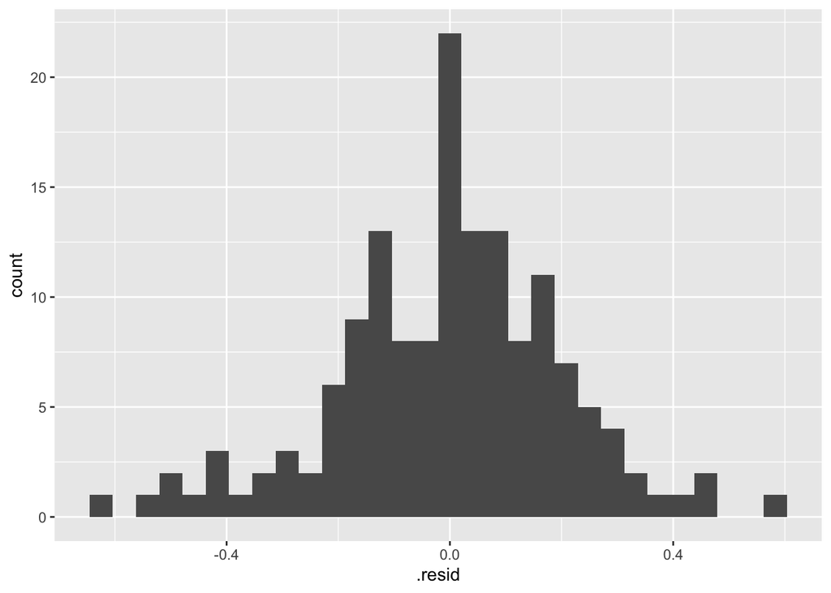

```r
ggplot(data = lm_fitted, aes(x = .resid)) +
  geom_histogram()
```

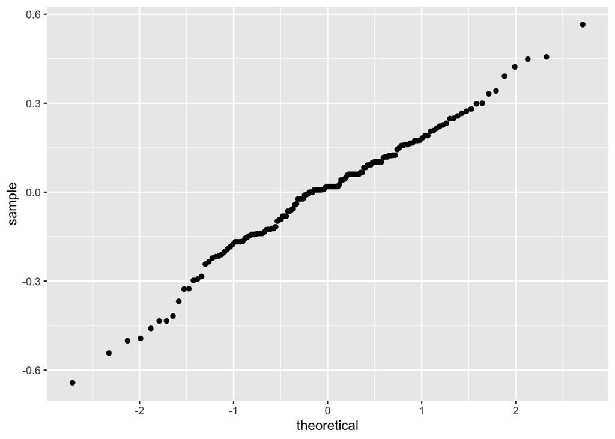

```r
ggplot(data = lm_fitted, aes(sample = .resid)) +
  geom_qq()
```

Check! These overall look pretty normally distributed.

We could also do a formal test for normality (e.g. Shapiro-Wilke, Anderson-Darling, etc.), but remember - those formal hypothesis tests for normality are often more an indication of sample size than a meaningful divergence from normality, especially as sample size increases).

2. Homoscedasticity

The assumption of homoscedasticity means that we assume relatively constant variance of residuals. Does it look like the variance (spread) of residuals changes over the span of the model?

Here, we’ll look at the residuals (actual, and standardized) over the course of the fitted values to see if the spread of the residuals is changing notably:

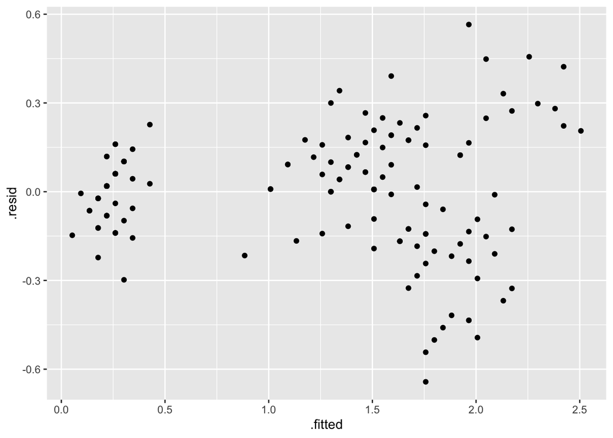

```r
ggplot(data = lm_fitted, aes(x = .fitted, y = .resid)) +
  geom_point()
```

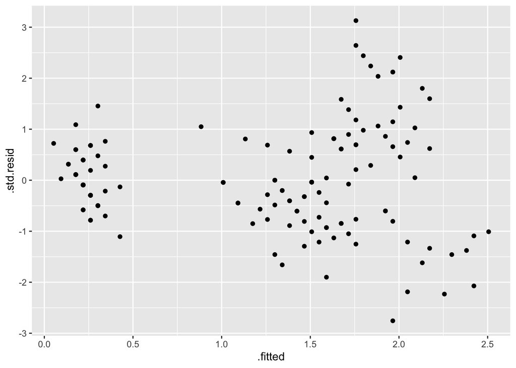

```r
ggplot(data = lm_fitted, aes(x = .fitted, y = .std.resid)) +
  geom_point()
```

There, we might say “Well yeah…it looks like at larger values of the fitted model, we see greater spread of the residuals.” But also try not to be distracted by a relatively small number of observations. Here, there are only about ~10 observations that look like they are leading to the larger residuals variance, and even those aren’t much different from the spread that exists at lower values in the fitted model (e.g. |0.5| vs. |0.3|). So here, heteroscedasticity isn’t a big concern.

Also remember, violations of homoscedasticity may lead to wrongly large or small *errors* associated with coefficients, but will not affect the model estimates (coefficients) themselves.

So the graphs we made manually above help us to explore the assumptions of linear regression (residuals normally distributed, ~ constant variance, and a linear model makes sense to describe the overall relationship between petal length and petal width).

An alternate approach to make those graphs (that you’re more likely to use, and is fine): Just get the diagnostic plots using `plot(model_name)`:

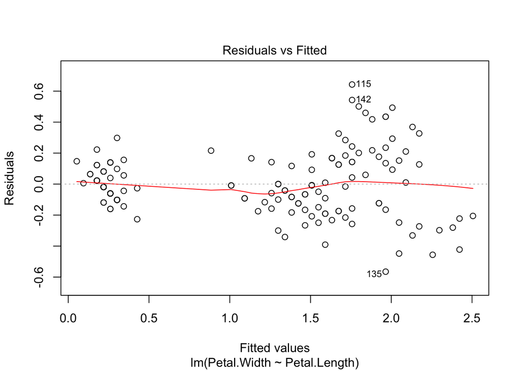

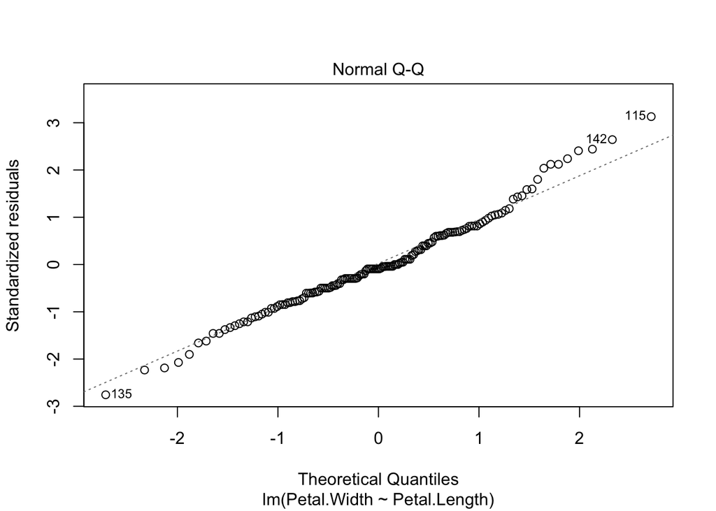

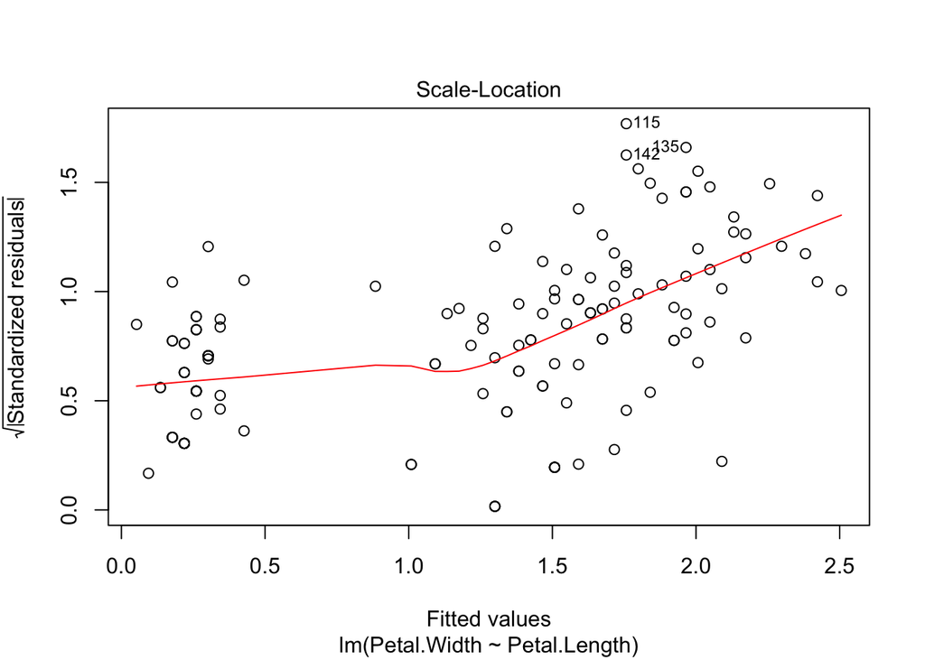

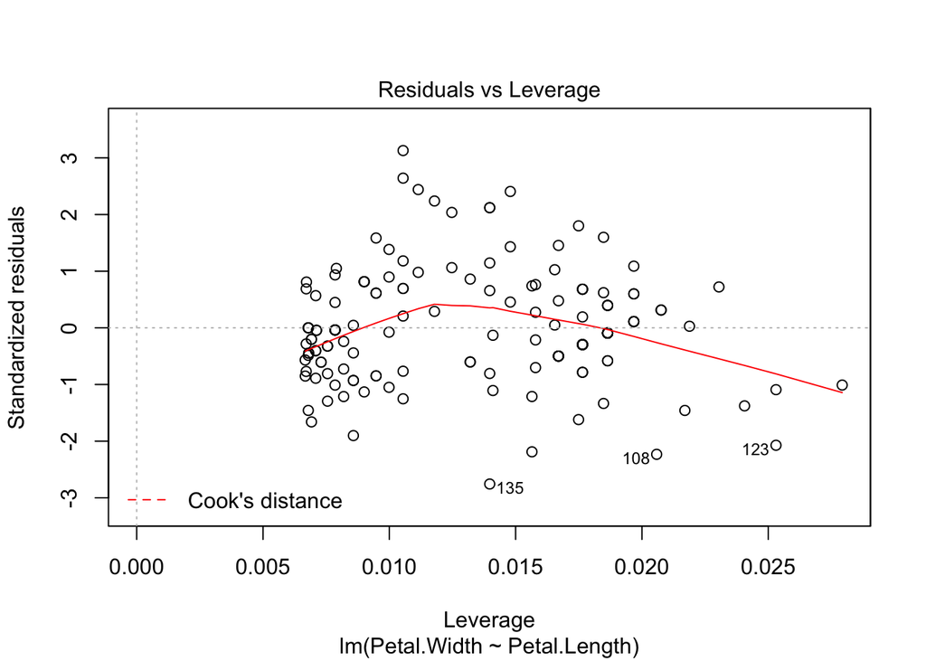

```r
plot(iris_lm)
```

Notice that four plots show up. What do they show?

- **The first one**: fitted values vs. residuals - the same that we made manually to explore homoscedasticity
- **The second one**: QQ-plot for residuals - the same that we made manually to explore normality of residuals
- **The third one**: another way of looking at fitted vs. residuals (these are just standardized residuals, but you can interpret it the same way)
- **The fourth one**: Cook’s distance, a measure of “influence” or “leverage” that individual points have on the model - often considered a way to explore outliers…

So let’s think a bit about Cook’s distance (Cook’s *d*): a measure of how “influential” a point is in the model output.

#### E. Cook’s Distance (observation influence / leverage)

Some guidelines:

- If Cook’s D is greater than $\frac{4}{n}$ for any observation, where *n* is the number of observations used to create the model, then that observation is strongly influential. This does NOT mean you should just remove that observation. In fact, you should plan on leaving all observations in unless you have really good reason not to.
- In our example (iris), *n* = 150, so the threshold for a second look is 4/150. Let’s make & store that as a variable here:

```r
cook_limit <- as.numeric(4 / count(iris))
```

Let’s take a look at the Cook’s distance for each of our observations, which is also included in `lm_fitted` as `.cooksd`:

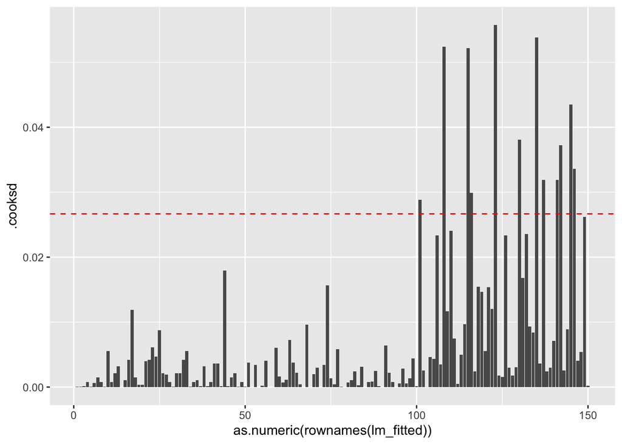

```r
# Note: here, we convert the numbered row names to actual values to be plotted on the x-axis, then plot Cook's d for each observation as a column height

ggplot(data = lm_fitted, aes(x = as.numeric(rownames(lm_fitted)), y = .cooksd)) +
  geom_col() +
  geom_hline(yintercept = cook_limit,
             color = "red",
             linetype = "dashed")
```

We can see that there are a number (though relatively small, ~ 12 of 150 observations) of observations that we might want to take a second look at. But Cook’s distance should **NOT** be a binary decision making tool to decide whether or not a value should be considered an outlier, or excluded from a dataset.

You should have a very compelling reason to believe that an observation is not representative of the population that you are trying to study (e.g. measurement error, mislabeled sample, etc.) before you even consider removing it. Your default should be to keep everything. How different a point is from the others is not a good enough reason to remove it from your analyses.

#### F. Visualize the model

Now that we’ve explore the assumptions and have decided that linear regression is a valid tool to describe the relationship between petal length and petal width, let’s look at the model.

- Use `geom_smooth(method = "lm")` to add a linear model to an existing scatterplot.
- Use `stat_cor()` and `stat_regline_equation` to add equation information directly to the plot panel, at an x- and y-position that you specify

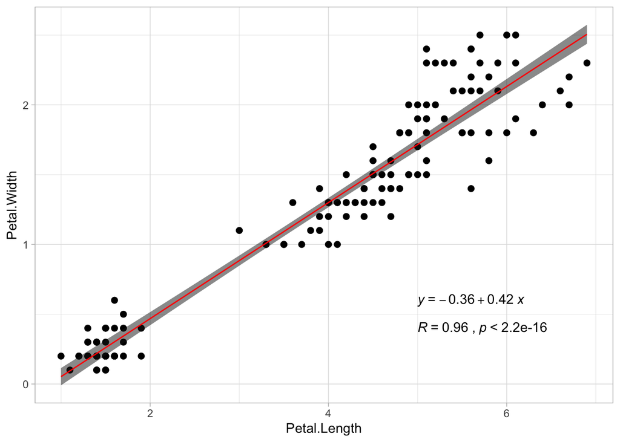

```r
ggplot(data = iris, aes(x = Petal.Length, y = Petal.Width)) +
  geom_point(size = 2) +
  geom_smooth(method = "lm",
              color = "red",
              size = 0.5,
              fill = "gray10",
              alpha = 0.5) +
  theme_light() +
  ggpubr::stat_cor(label.x = 5, label.y = 0.4) +
  ggpubr::stat_regline_equation(label.x = 5, label.y = 0.6)
```

#### G. Make predictions at new points

Often, we’ll want to use a model to make predictions for **new** values of the predictor variable.

Let’s make a data frame of new petal lengths, then feed that into the `iris_lm` model to make predictions for petal width.

**Note**: Notice that here, I’m creating a variable called `Petal.Length` within new_df. That’s important because the model `iris_lm` was built using a predictor variable called `Petal.Length`, so when we feed the model new data it is going to look for a variable *also called Petal.Length*.

```r
# Make a new data frame (in this case, containing only a single column called Petal.Length):
new_df <- data.frame(Petal.Length = c(2.5, 3, 3.5))

# Look at new_df to confirm:
new_df
```

```
##   Petal.Length
## 1          2.5
## 2          3.0
## 3          3.5
```

Now, give that new data for Petal.Length (in new_df) to the model to make predictions, using the `predict()` function:

```r
predicted_values <- predict(iris_lm, newdata = new_df)

# Put the predictions together with the inputs if you want:
new_predict <- data.frame(new_df, predicted_values)
new_predict
```

```
##   Petal.Length predicted_values
## 1          2.5        0.6763130
## 2          3.0        0.8841907
## 3          3.5        1.0920684
```

#### H. Find Pearson’s *r* for correlation:

In lecture we talked about the coefficient of determination, R<sup>2</sup>, which tells us how much of the variance in the dependent variable is explained by the model.

We might also want to explore the strength of the correlation (degree of relationship) between two variables which, for two linearly related continuous variables, can be expressed using Pearson’s *r*.

Pearson’s *r* ranges in value from -1 (perfectly negatively correlated - as one variable increases the other decreases) to 1 (perfectly positively correlated - as one variable increases the other increases). A correlation of 0 means that there is no degree of relationship between the two variables.

Typical guidelines look something like this (there’s wiggle room in there):

- *r* = 0: no correlation
- *r* < |0.3|: weak correlation
- *r* between |0.3| and |0.7|: moderate correlation
- *r* > |0.7|: strong correlation

We’ll use the `cor.test()` function, adding the two vectors (Petal.Length and Petal.Width from iris) as the arguments. The function reports the Pearson’s *r* value, and performs a hypothesis test with null hypothesis that the correlation = 0.

```r
my_cor <- cor.test(iris$Petal.Length, iris$Petal.Width)
# r = 0.9629 (strong positive correlation)
# Correlation is significantly non-zero
```

Here, we see that there is a strong positive correlation between petal length and petal width (*r* = 0.96, t(148) = 43.39, p < 0.001).